# Supervised Learning

Cinthya Figueroa, David Vidal, Valeri Suárez

22/01/2024

# Detección de ataques con aprendizaje supervisado

El siguiente ejercicio consiste en la optmización de un modelo de Machine Learning capaz de detectar ataques a partir de logs de un firewall. Para este propósito, se realizará una prueba de concepto con una pequeña muestra de logs previamente etiquetados como tráfico normal o ataque.

## Load of the data sets

Se proporcionan los siguentes archivos:

- features.csv
- events.csv

### Events analysis/exploration

```
## [1] "El volumen de la muestra es 10000"
```

```
##  [1] "srcip"            "sport"            "dstip"            "dsport"
##  [5] "proto"            "state"            "dur"              "sbytes"
##  [9] "dbytes"           "sttl"             "dttl"             "sloss"
## [13] "dloss"            "service"          "Sload"            "Dload"
## [17] "Spkts"            "Dpkts"            "swin"             "dwin"
## [21] "stcpb"            "dtcpb"            "smeansz"          "dmeansz"
## [25] "trans_depth"      "res_bdy_len"      "Sjit"             "Djit"
## [29] "Stime"            "Ltime"            "Sintpkt"          "Dintpkt"
## [33] "tcprtt"           "synack"           "ackdat"           "is_sm_ips_ports"
## [37] "ct_state_ttl"     "ct_flw_http_mthd" "is_ftp_login"     "ct_ftp_cmd"
## [41] "ct_srv_src"       "ct_srv_dst"       "ct_dst_ltm"       "ct_src_ltm"
## [45] "ct_src_dport_ltm" "ct_dst_sport_ltm" "ct_dst_src_ltm"   "attack_cat"
## [49] "Label"
```

```
## 'data.frame':    10000 obs. of  49 variables:
##  $ srcip           : chr  "59.166.0.3" "59.166.0.4" "59.166.0.6" "59.166.0.7" ...
##  $ sport           : int  44826 54490 28628 21744 64008 33838 500 3165 12795 14587 ...
##  $ dstip           : chr  "149.171.126.9" "149.171.126.2" "149.171.126.9" "149.171.126.2" ...
##  $ dsport          : int  22 80 80 53 21 111 500 53214 49012 80 ...
##  $ proto           : chr  "tcp" "tcp" "tcp" "udp" ...
##  $ state           : chr  "FIN" "FIN" "FIN" "CON" ...
##  $ dur             : num  0.95895 1.00566 1.09305 0.00103 0.93388 ...
##  $ sbytes          : int  12648 1580 1684 146 634 568 712 2334 320 1580 ...
##  $ dbytes          : int  13098 10168 10168 178 682 312 0 16632 1878 10168 ...
##  $ sttl            : int  31 31 31 31 254 31 254 31 31 31 ...
##  $ dttl            : int  29 29 29 29 252 29 0 29 29 29 ...
##  $ sloss           : int  35 3 3 0 3 0 0 7 1 3 ...
##  $ dloss           : int  33 5 5 0 4 0 0 12 2 5 ...
##  $ service         : chr  "ssh" NA "http" "dns" ...
```

[output cut: 35 more lines]

```
##
##    10.40.170.2    10.40.182.1    10.40.182.3    10.40.182.6     10.40.85.1
##              9             26             12              7             20
##    10.40.85.10    10.40.85.30  149.171.126.0 149.171.126.10 149.171.126.12
##              6              6              1            128             76
## 149.171.126.14 149.171.126.15 149.171.126.18  149.171.126.2  149.171.126.3
##            155            195            347              2              1
##  149.171.126.4  149.171.126.5  149.171.126.6  149.171.126.8  149.171.126.9
##              2              1              1              2              1
##   175.45.176.0   175.45.176.1   175.45.176.2   175.45.176.3     59.166.0.0
##            323            505            120            453            757
##     59.166.0.1     59.166.0.2     59.166.0.3     59.166.0.4     59.166.0.5
##            750            731            750            789            802
##     59.166.0.6     59.166.0.7     59.166.0.8     59.166.0.9
##            754            744            798            726
```

```
##
##                           Fuzzers         Fuzzers   Reconnaissance
##             8749               16               81               61
##       Shellcode          Analysis         Backdoor        Backdoors
##                4               14                6                1
##              DoS         Exploits          Generic   Reconnaissance
##               59              174              832                2
##        Shellcode
##                1
```

## Feature engineering

```
##
## ATTACK NORMAL
## 0.1251 0.8749
```

## Build model

### Create train and test data sets

### Prepare object with training configuration (how we are gonna train the model)

## Evaluate model

```
##  Accuracy     Kappa
## 0.9944444 0.9746034
```

```r
# probabilites
predictions <- predict(object = objModel, testDF[,predictorsNames], type = 'prob')
auc <- pROC::roc(ifelse(testDF[,outcomeName] == "ATTACK",1,0), predictions[[2]])
print(auc$auc)
```

```
## Area under the curve: 0.9996
```

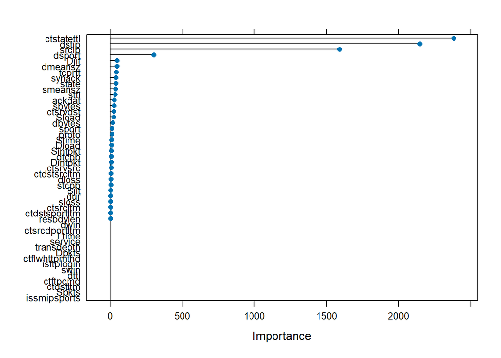

```r
plot(caret::varImp(objModel, scale = F))
```

## Conclusiones

Para obtener una mejor precisión de los datos se realizaron algunas validaciones, y variaciones de datos y métodos. Se varió el valor de p a 0.28 con 9 particiones (se utilizan para dividir un conjunto de datos en conjuntos de entrenamiento y prueba), además también se cambió el método de entrenamiento a validación cruzada (cv) y se definió un número de pliegues de 10, y estas variaciones mejoraron el accuracy de 0.9837312 a 0.9944444, así mismo se obtuvo una mejora en el valor Kappa de 0.9277821 a 0.9746034.

Se realizó variaciones al valor de p a 0.28 con 10 particiones, pero estos cambios nos daban un valor de área bajo la curva (AUC-ROC) de 1 y aunque un 1 indica que el modelo tiene una precisión perfecta, generalmente se considera sospechoso y podría indicar la necesidad de más validación o revisión del modelo, es decir, el modelo podría estar capturando ruido en los datos de entrenamiento en lugar de las señales subyacentes, lo que podría llevar a un rendimiento deficiente en datos no vistos.

Por todo lo anterior descartamos este cambio para que el valor de área bajo la curva fuera inferior a 1 aunque bajara levemente el accuracy.

Es importante recordar que un buen modelo de aprendizaje automático no solo se ajusta bien a los datos de entrenamiento, sino que también generaliza bien a los datos no vistos.